# presentation-live

## Jak vytvoříme obrázek z měření tučňáků a uchováme jeho postup?

BIOSTATISTIKA

L00

První kroky v R a RStudiu

cuni-natur-biostatistics.github.io/materialy.html

## Jak vytvoříme obrázek z měření tučňáků a uchováme jeho postup?

| druh | délka křídla (mm) | hmotnost (g) |
| --- | --- | --- |
| Adelie | 181 | 3750 |
| Adelie | 186 | 3800 |
| Adelie | 195 | 3250 |
| Adelie | 193 | 3450 |

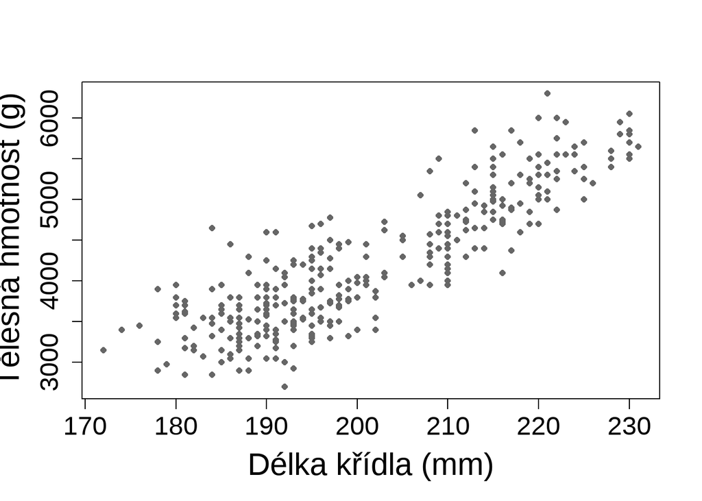

Měření v tabulce, obrázek a postup, který je spojuje.

## Výsledky učení

Po absolvování této lekce budete schopni:

- orientovat se v okně RStudia
- uložit a spustit zapsané pokyny
- otevřít tabulku CSV a vytvořit obrázek
- po čistém spuštění R obnovit výsledek

## Kdy je užitečnější uložit postup než opakovat klikání?

### Tabulkový procesor

- rychlé otevření malé tabulky
- pohodlná ruční kontrola
- několik drobných změn

### Uložený textový postup

- stejné kroky pro nová data
- přesná kontrola provedených kroků
- oprava jednoho kroku bez hádání

Tabulkový procesor a R se mohou doplňovat. Uložený postup je výhodný hlavně tehdy, když potřebujeme práci přesně opakovat.

## R provádí zapsané příkazy, RStudio poskytuje pracovní okno

R

Programovací jazyk a program, který provádí přesné textové pokyny zvané **kód**.

RStudio

Okno, ve kterém kód píšeme, ukládáme, posíláme do R a kontrolujeme výsledky.

## Kde hledat zapsané příkazy, odpověď R, paměť a obrázek?

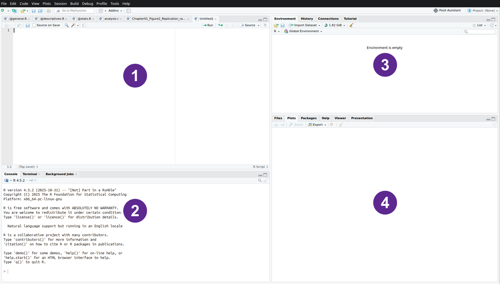

**1 Source** · **2 Console** · **3 Environment** · **4 Files, Plots, Packages a Help**

Snímek: [Rcragun, Wikimedia Commons](https://commons.wikimedia.org/wiki/File:RStudio_-_Fresh_Install.png), CC BY-SA 4.0; číselné značky doplněny pro tuto lekci.

## Source uchovává skript, Console ukazuje odpověď R

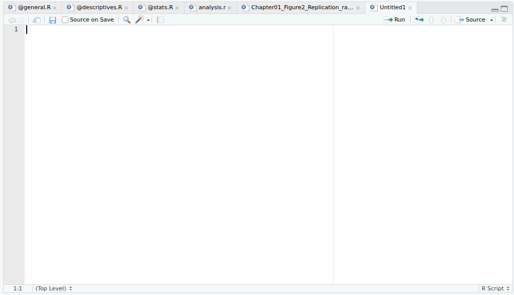

**Source** je textový editor. Skript je uložený soubor s kódem a koncovkou `.R`.

[figure not shown]

**Console** je přímé spojení s běžícím R. Značka `>` znamená, že R čeká na příkaz.

Klikněte za `>`, napište `1 + 1` a stiskněte **Enter**.

Snímek: [Rcragun, Wikimedia Commons](https://commons.wikimedia.org/wiki/File:RStudio_-_Fresh_Install.png), CC BY-SA 4.0; výřezy upraveny pro tuto lekci.

## Co ukazují dvě pravé oblasti RStudia?

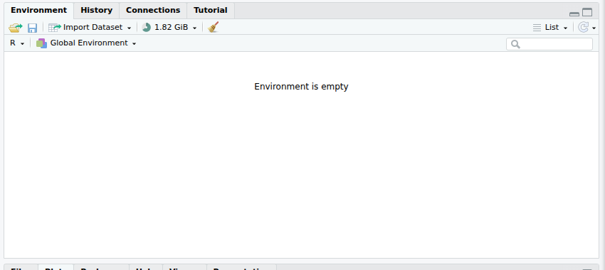

**Environment** ukazuje pojmenované výsledky v paměti právě běžícího R.

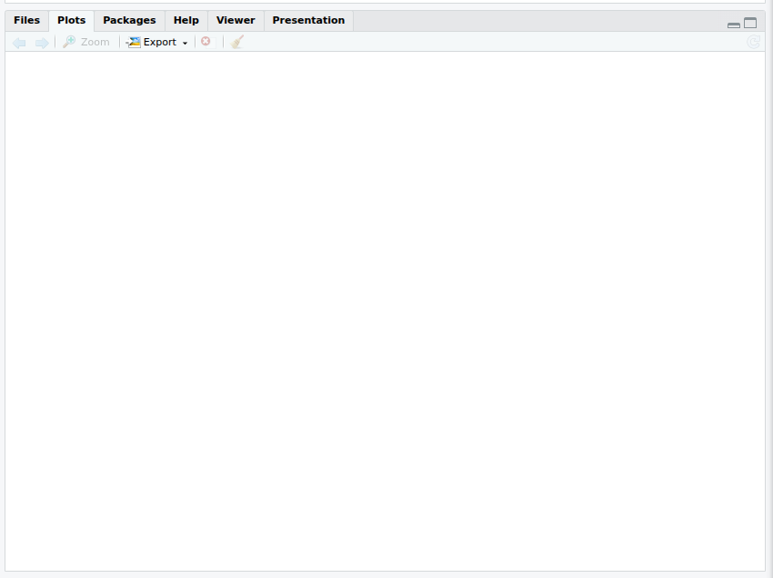

**Files** ukazuje soubory, **Plots** obrázky a **Help** nápovědu. Záložky sdílejí jedno místo.

## Jak se řádek ze skriptu dostane k R?

| Source | Klávesa | Console |
| --- | --- | --- |
| `2 + 3` | **Ctrl + Enter** | příkaz a výsledek |

Ctrl + S

Uloží text skriptu do souboru.

Ctrl + Enter

Pošle aktuální řádek nebo označenou část do R.

## Co znamená značka `+` na začátku řádku?

`> (2 + 3`

`+`

Na co R čeká?

Příkaz není dokončený

Chybí pravá závorka. Klávesa **Esc** vrátí běžnou značku `>`; opravený příkaz je `(2 + 3)`.

## Projekt je jedna složka práce otevřená v RStudiu

```
prvni-kroky-r/
├── prvni-kroky-r.Rproj
├── data/
│   └── palmer_penguins.csv
├── vystupy/
└── prvni_kroky.R
```

- `.Rproj` otevře složku jako projekt
- `data` obsahuje vstupní tabulku
- `vystupy` obsahuje uložené výsledky
- `prvni_kroky.R` uchovává kód

Zkontrolujte stejnou strukturu v záložce Files a název projektu vpravo nahoře.

## Kdy se pojmenovaný výsledek objeví v Environment?

```r
# Uložíme délku lekce v minutách
delka_lekce_min <- 90
```

Stačí řádek napsat?

Objekt vznikne až po spuštění

Po **Ctrl + Enter** se `delka_lekce_min` objeví v Environment.

## Co změní nastavení `digits`?

```r
round(
  x = 3.14159,
  digits = 2
)
```

Očekávaný výsledek: **3.14**

- `round` je **funkce**, která číslo zaokrouhlí
- `x` je pojmenovaný **argument**: zaokrouhlované číslo
- `digits` je pojmenovaný **argument**: počet desetinných míst

Změňte `digits` a spusťte příkaz. Do Console napište `?round`; v Help najděte části Usage a Arguments.

## Odkud se v R berou další možnosti?

**Balíček** je nainstalovaný doplněk, který může přidat funkce, dokumentaci nebo data.

Instalace v Console

Obvykle ji provedeme pouze jednou.

`install.packages(pkgs = "palmerpenguins")`

Použití konkrétního obsahu

Dvojitá dvojtečka vybírá obsah z balíčku.

`names(x = palmerpenguins::penguins)`

Pokud instalace do pěti minut nefunguje, pokračujeme s připraveným CSV. Další kroky balíček nepotřebují.

## Jeden řádek patří jednomu tučňákovi

| druh | délka křídla (mm) | tělesná hmotnost (g) |
| --- | --- | --- |
| Adelie | 181 | 3750 |
| Adelie | 186 | 3800 |
| Adelie | 195 | 3250 |
| Adelie | 193 | 3450 |
| Adelie | 190 | 3650 |

První řádek popisuje jednoho tučňáka druhu **Adelie**: délka křídla **181 mm**, tělesná hmotnost **3750 g**.

Data: Gorman, Williams a Fraser; [Palmer Penguins](https://allisonhorst.github.io/palmerpenguins/), CC0.

## Cesta k datům začíná ve složce projektu

```
prvni-kroky-r/
└── data/
    └── palmer_penguins.csv
```

`data/palmer_penguins.csv` popisuje cestu od hlavní složky projektu.

```r
# Načteme CSV ze složky data
data_tucnaci <-
  read.csv(
    file = "data/palmer_penguins.csv"
  )
```

Po spuštění se `data_tucnaci` objeví v Environment.

## Jak poznáme, že jsme otevřeli správnou tabulku?

1. Jak vypadají první řádky?
2. Jak se jmenují sloupce?
3. Kolik řádků tabulka obsahuje?

```r
head(
  x = data_tucnaci,
  n = 6
)
names(x = data_tucnaci)
nrow(x = data_tucnaci)
```

Očekáváme sloupce **species, flipper_length_mm, body_mass_g** a **342 řádků**.

## Jeden tučňák vytvoří jeden bod

První řádek

Vodorovně: **181 mm**

Svisle: **3750 g**

Jeden řádek dodá bodu dvě souřadnice.

Znak `$` vybírá pojmenovaný sloupec tabulky.

```r
plot(
  x = data_tucnaci$flipper_length_mm,
  y = data_tucnaci$body_mass_g
)
```

`x` určuje vodorovnou a `y` svislou osu.

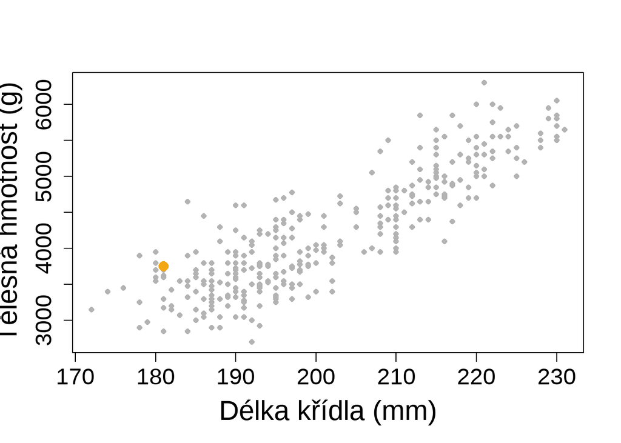

Najděte přibližnou polohu prvního tučňáka. Obrazec zatím statisticky nevykládáme.

## Plots ukazuje obrázek, PNG zůstává jako soubor

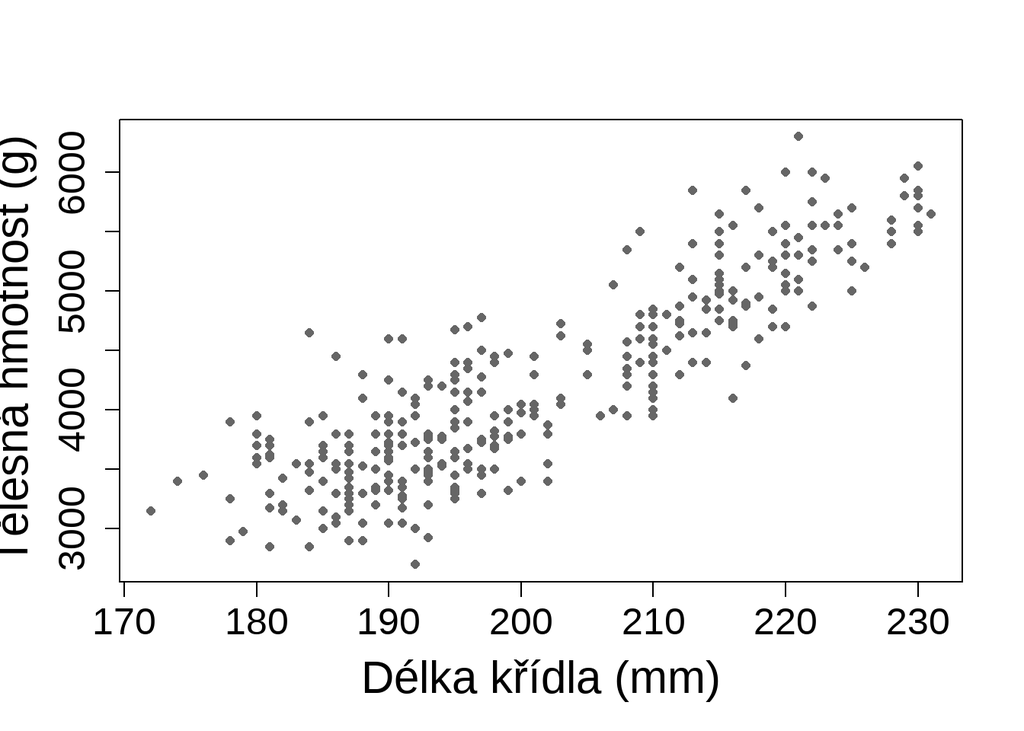

1. `png()` otevře cílový soubor.
2. Stejný `plot()` do něj nakreslí obrázek.
3. `dev.off()` soubor dokončí.

Soubor na disku

`vystupy/tucnaci.png`

## Co se při restartu R změní?

**Restart R ukončí právě běžící R uvnitř RStudia a spustí čistý běh. RStudio zůstane otevřené.**

| Co sledujeme | Zůstane, nebo zmizí? |
| --- | --- |
| uložený skript `prvni_kroky.R` | ? |
| vstupní CSV ve složce `data` | ? |
| PNG ve složce `vystupy` | ? |
| objekty v Environment | ? |

Soubory zůstanou na disku. Environment se vyčistí. Uložený skript může potřebné objekty a výstup obnovit.

## Co už umíme

- R provádí příkazy; RStudio poskytuje pracovní okno.
- Source uchovává skript; Console komunikuje s běžícím R.
- Environment je dočasná paměť; Files ukazuje soubory na disku.
- Plots ukazuje obrázek; PNG je uložený soubor.
- Uložený skript obnovil výsledek z uloženého CSV.

## Co byste poslali spolužákovi, aby výsledek obnovil?

A

Pouze obrázek `tucnaci.png`

B

Pouze skript `prvni_kroky.R`

C

Celou složku projektu se skriptem a vstupními daty

**C.** Obrázek ukazuje výsledek. Projekt se skriptem a daty navíc ukazuje, jak výsledek vznikl.